# network_hw5

Network_HW5_ Centrality (Individual-level)  
r09228001 臺大地理所碩一 楊宇翔 2021/4/07 (Wed.)

Q5-1 網絡分析實作 利用 data(studentnets.peerinfl, package=“NetData”) 提供的資料表（https://www.rdocumentation.org/packages/NetData/versions/0.3/topics/peerinfl），檢視 sem1, sem2資料表的欄位std_id / alter_id，表示某班級兩學期的同學友誼的指認關係。

• 作業5-1提供data(studentnets.peerinfl) 的sem1，該表格為某校在某學期的各班同學指認不同類型的朋友關係的調查。

• 請先篩選出班級（cls_id）為508的edges，再針對會一起「參加學校活動（acta）」以及「參加校外活動（nacta）」的關係，分別建立好友網絡，計算network centrality的各種指標（利用套件的函數），比較這些同學在班上人際網絡的關係（如比較每個人在「學校活動」網絡與「校外活動」網絡的差異等）。

欄位說明： • std_id - student id • alter_id - alter id • cls_id - class id • acta - In school activities (1 = yes, 0 = np) • nacta - Non-school activities (1 = yes, 0 = no)

How we measure the centrality:Freeman’s Measures: Degree, closeness, and betweenness Network-level centralization: More indices: Information centrality and Eigenvector centrality Directed network centrality: HITS and PageRank algorithms Spatial network centrality: Geo-location + PageRank

```r
#install.packages("spData")
#install.packages("NetData")
rm(list=ls(all=TRUE))
library(igraph)
library(spData)
library(NetData)
```

```r
data(studentnets.peerinfl)
preVtable<- attitudes[attitudes$cls_id == "508",]
Vtable <- preVtable$std_id
Etable <- sem1[sem1$cls_id == "508",]
```

### g1=Inside the school

```r
Etable1 <- Etable[Etable$acta == 1,]
g1 = graph.data.frame (Etable1, directed=F, Vtable)
```

### g2= Outside the School

```r
Etable2 <- Etable[Etable$nacta == 1,]
g2 = graph.data.frame (Etable2, directed=TRUE, Vtable)
```

# 1.1 Freeman’s Measures: Degree

### Centrality is fairly straight forward: we want to identify which nodes are in the ‘center’ of the network.

## Inside the school

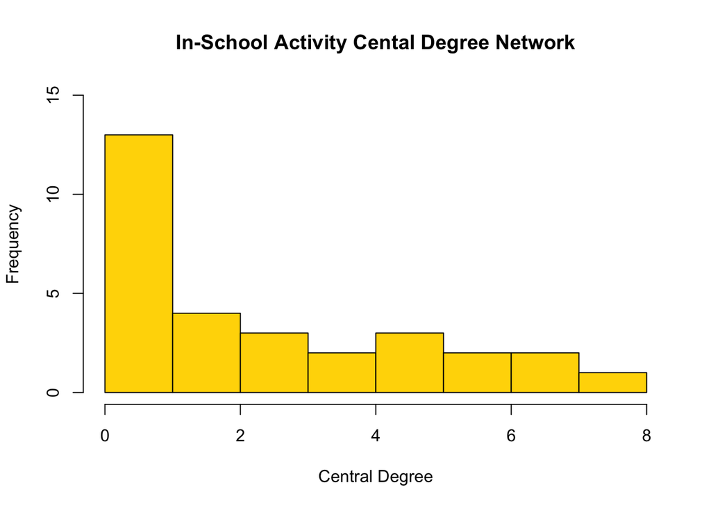

```r
d1 <- degree(g1, v = V(g1), mode = c("all", "out", "in", "total"), loops = TRUE, normalized = F)
hist(d1,ylim = c(0, 15),col="gold",xlab="Central Degree", main="In-School Activity Cental Degree Network")
```

```r
d1
```

```
## 14833 14843 14851 14853 14927 15003 15037 14736 14826 14986 15120 15129 14824
##     0     2     2     0     1     5     8     7     1     7     6     3     0
## 14866 15010 15076 15130 14739 14746 14812 14834 14953 14954 14951 14972 15014
##     0     0     0     0     2     5     5     4     4     6     0     0     2
## 15061 15065 15086 15177
##     3     3     0     0
```

```r
summary(d1)
```

```
##    Min. 1st Qu.  Median    Mean 3rd Qu.    Max.
##   0.000   0.000   2.000   2.533   4.750   8.000
```

## Outside the School

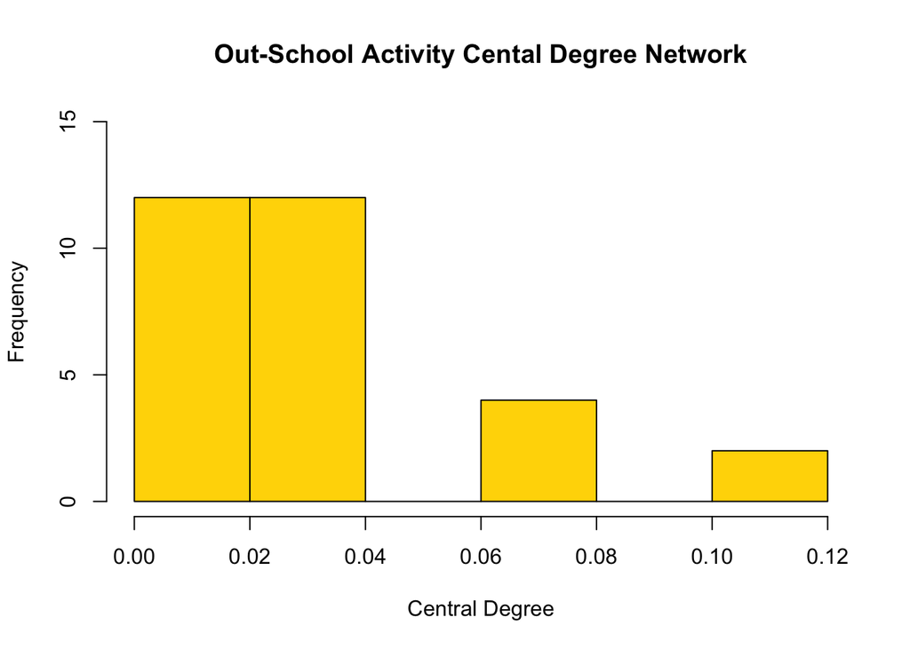

```r
d2 <- degree(g2, v = V(g2), mode = c("all", "out", "in", "total"), loops = TRUE, normalized = T)
hist(d2,ylim = c(0, 15),col="gold",xlab="Central Degree", main="Out-School Activity Cental Degree Network")
```

```r
d2
```

```
##      14833      14843      14851      14853      14927      15003      15037
## 0.00000000 0.03448276 0.03448276 0.00000000 0.00000000 0.03448276 0.03448276
##      14736      14826      14986      15120      15129      14824      14866
## 0.10344828 0.00000000 0.03448276 0.06896552 0.00000000 0.03448276 0.00000000
##      15010      15076      15130      14739      14746      14812      14834
## 0.00000000 0.06896552 0.00000000 0.03448276 0.03448276 0.03448276 0.06896552
##      14953      14954      14951      14972      15014      15061      15065
## 0.03448276 0.10344828 0.03448276 0.00000000 0.00000000 0.00000000 0.00000000
##      15086      15177
## 0.03448276 0.06896552
```

```r
summary(d2)
```

```
##    Min. 1st Qu.  Median    Mean 3rd Qu.    Max.
## 0.00000 0.00000 0.03448 0.02989 0.03448 0.10345
```

# 1.2 Freeman’s Measures:closeness

#An actor is considered important if he/she is relatively close to all other actors. #Closeness is based on the inverse of the distance of each actor to every other actor in the network.

## Inside the school

```r
dist1 <- distances(g1)
sp1 <- shortest_paths(g1,from = V(g1)[2] , to = V(g1))
#sp1$vpath
c1=closeness(g1, vids = V(g1), mode = c("out", "in", "all", "total"), weights = NULL, normalized = FALSE)
```

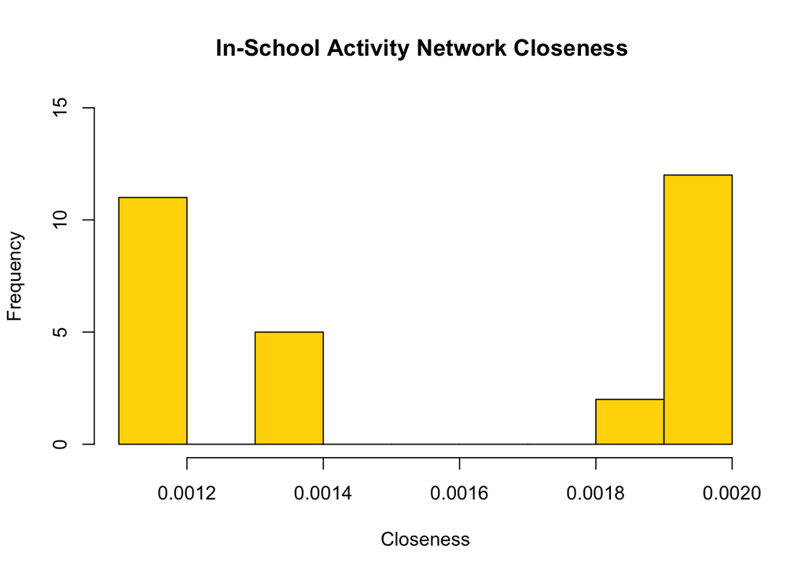

```r
hist(c1,ylim = c(0, 15),col="gold",xlab="Closeness", main="In-School Activity Network Closeness ")
```

```r
c1
```

```
##       14833       14843       14851       14853       14927       15003
## 0.001149425 0.001953125 0.001926782 0.001149425 0.001845018 0.001976285
##       15037       14736       14826       14986       15120       15129
## 0.001960784 0.001949318 0.001912046 0.001956947 0.001945525 0.001953125
##       14824       14866       15010       15076       15130       14739
## 0.001149425 0.001149425 0.001149425 0.001149425 0.001149425 0.001915709
##       14746       14812       14834       14953       14954       14951
## 0.001324503 0.001324503 0.001960784 0.001326260 0.001326260 0.001149425
##       14972       15014       15061       15065       15086       15177
## 0.001149425 0.001322751 0.001923077 0.001886792 0.001149425 0.001149425
```

```r
summary(c1)
```

```
##     Min.  1st Qu.   Median     Mean  3rd Qu.     Max.
## 0.001149 0.001149 0.001326 0.001544 0.001941 0.001976
```

## Outside the School

```r
dist2 <- distances(g2)
sp2 <- shortest_paths(g2,from = V(g2)[2] , to = V(g2))
#sp1$vpath
c2=closeness(g2, vids = V(g2), mode = c("out", "in", "all", "total"), weights = NULL, normalized = FALSE)
```

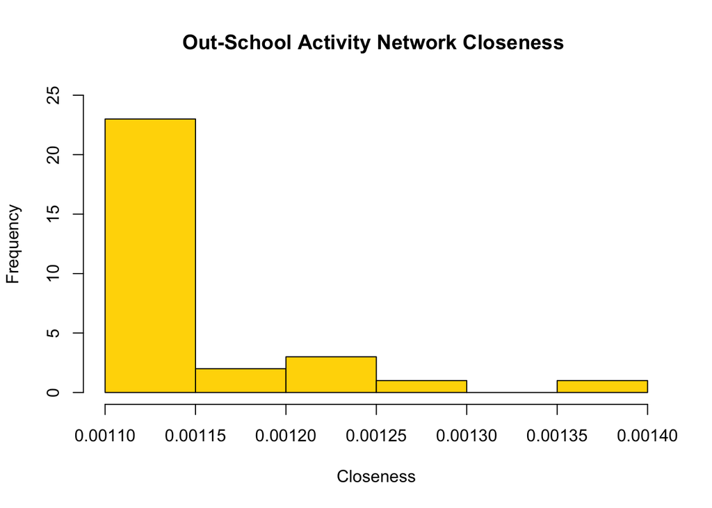

```r
hist(c2,ylim = c(0, 25),col="gold",xlab="Closeness", main="Out-School Activity Network Closeness ")
```

```r
c2
```

```
##       14833       14843       14851       14853       14927       15003
## 0.001149425 0.001189061 0.001149425 0.001149425 0.001149425 0.001149425
##       15037       14736       14826       14986       15120       15129
## 0.001149425 0.001373626 0.001149425 0.001149425 0.001230012 0.001149425
##       14824       14866       15010       15076       15130       14739
## 0.001149425 0.001149425 0.001149425 0.001231527 0.001149425 0.001149425
##       14746       14812       14834       14953       14954       14951
## 0.001149425 0.001149425 0.001189061 0.001149425 0.001277139 0.001149425
##       14972       15014       15061       15065       15086       15177
## 0.001149425 0.001149425 0.001149425 0.001149425 0.001149425 0.001231527
```

```r
summary(c2)
```

```
##     Min.  1st Qu.   Median     Mean  3rd Qu.     Max.
## 0.001149 0.001149 0.001149 0.001172 0.001149 0.001374
```

# 1.3 Freeman’s Measures:betweenness

#A person who lies on communication paths can control communication flow, and is thus important. #Betweenness counts the number of shortest paths between i and k that actor j resides on.

## Inside the school

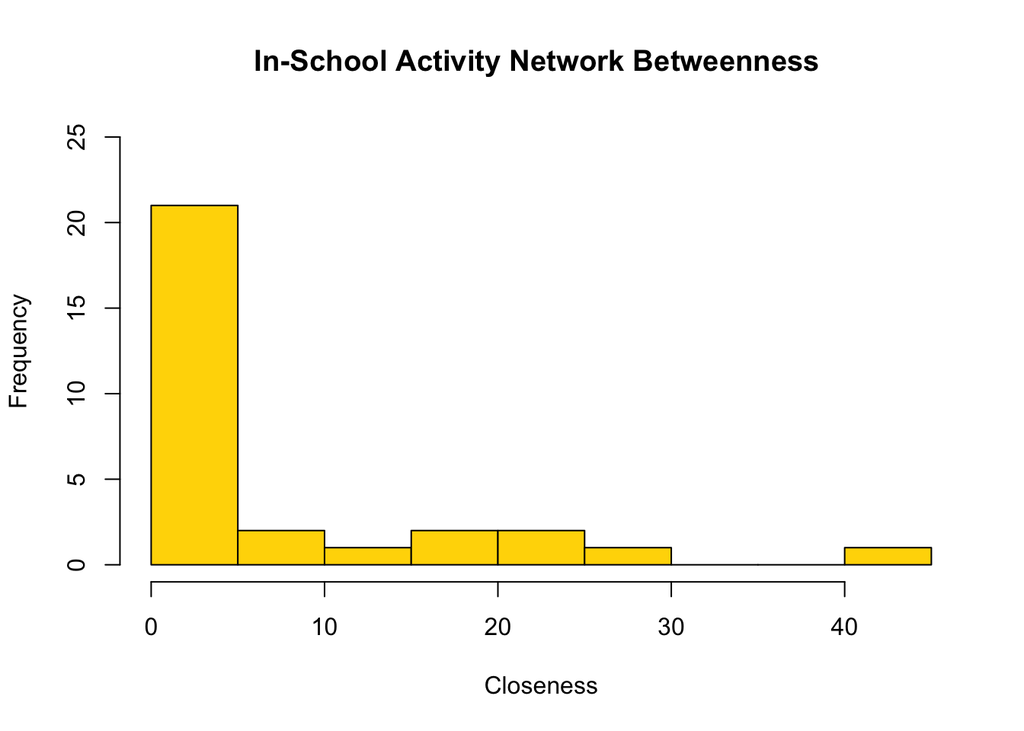

```r
vb1<- betweenness(g1, v = V(g1), directed = TRUE, weights = NULL, nobigint = TRUE, normalized = FALSE)
hist(vb1,ylim = c(0, 25),col="gold",xlab="Closeness", main="In-School Activity Network Betweenness ")
```

```r
vb1
```

```
##      14833      14843      14851      14853      14927      15003      15037
##  0.0000000 30.0000000  0.0000000  0.0000000  0.0000000 41.5000000 16.6666667
##      14736      14826      14986      15120      15129      14824      14866
##  5.3333333  0.0000000 20.5000000  1.0000000  6.6666667  0.0000000  0.0000000
##      15010      15076      15130      14739      14746      14812      14834
##  0.0000000  0.0000000  0.0000000  0.0000000  0.0000000  0.0000000 15.3333333
##      14953      14954      14951      14972      15014      15061      15065
##  0.6666667  1.3333333  0.0000000  0.0000000  0.0000000 22.0000000 12.0000000
##      15086      15177
##  0.0000000  0.0000000
```

```r
summary(vb1)
```

```
##    Min. 1st Qu.  Median    Mean 3rd Qu.    Max.
##   0.000   0.000   0.000   5.767   6.333  41.500
```

## Outside the School

[figure not shown]

```r
vb2<- betweenness(g2, v = V(g2), directed = TRUE, weights = NULL, nobigint = TRUE, normalized = FALSE)
hist(vb2,ylim = c(0, 30),col="gold",xlab="Closeness", main="In-School Activity Network Betweenness ")
```

```r
vb2
```

```
## 14833 14843 14851 14853 14927 15003 15037 14736 14826 14986 15120 15129 14824
##     0     0     0     0     0     0     0     0     0     0     2     0     0
## 14866 15010 15076 15130 14739 14746 14812 14834 14953 14954 14951 14972 15014
##     0     0     0     0     0     0     0     2     0     0     0     0     0
## 15061 15065 15086 15177
##     0     0     0     0
```

```r
summary(vb2)
```

```
##    Min. 1st Qu.  Median    Mean 3rd Qu.    Max.
##  0.0000  0.0000  0.0000  0.1333  0.0000  2.0000
```

# 1.4 Network-Level Degree Centralization

此指標將centralization視為是actors之間的分散程度(dispersion)或異質程度(heterogeneity)

## Inside the school

```r
centr_degree(g1)
```

```
## $res
##  [1] 0 2 2 0 1 5 8 7 1 7 6 3 0 0 0 0 0 2 5 5 4 4 6 0 0 2 3 3 0 0
##
## $centralization
## [1] 0.1885057
##
## $theoretical_max
## [1] 870
```

```r
centr_degree(g2)
```

```
## $res
##  [1] 0 1 1 0 0 1 1 3 0 1 2 0 1 0 0 2 0 1 1 1 2 1 3 1 0 0 0 0 1 2
##
## $centralization
## [1] 0.03804994
##
## $theoretical_max
## [1] 1682
```

# 1.5 Eigenvector centrality

The corresponding entry of the principal eigenvector of the adjacency matrix of the network.It assigns relative scores to all nodes in the network based on the principle that connections to high-scoring nodes contribute more.

## Inside the school

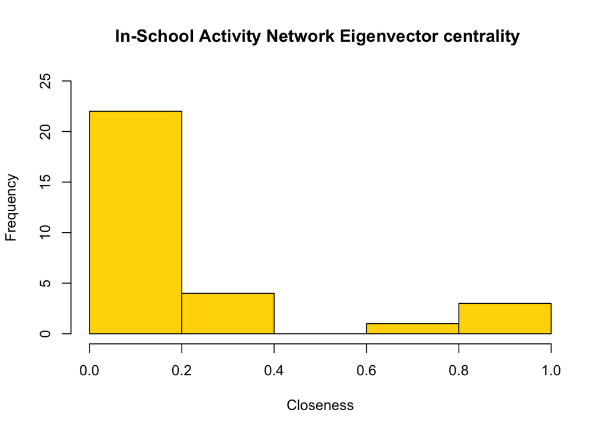

```r
ec <- eigen_centrality(g1, directed = FALSE, scale = TRUE,weights = NULL, options = arpack_defaults)
ec1 <- ec$vector
hist(ec1,ylim = c(0, 25),col="gold",xlab="Closeness", main="In-School Activity Network Eigenvector centrality ")
```

```r
ec1
```

```
##        14833        14843        14851        14853        14927        15003
## 0.000000e+00 5.369102e-02 3.413434e-01 0.000000e+00 6.688384e-04 2.975721e-01
##        15037        14736        14826        14986        15120        15129
## 9.597872e-01 1.000000e+00 1.366099e-01 7.843313e-01 9.559067e-01 2.402684e-01
##        14824        14866        15010        15076        15130        14739
## 0.000000e+00 0.000000e+00 0.000000e+00 0.000000e+00 0.000000e+00 7.470779e-02
##        14746        14812        14834        14953        14954        14951
## 5.400702e-17 2.700351e-17 2.144634e-01 5.400702e-17 0.000000e+00 0.000000e+00
##        14972        15014        15061        15065        15086        15177
## 0.000000e+00 0.000000e+00 1.068924e-02 3.840064e-03 0.000000e+00 0.000000e+00
```

```r
summary(ec1)
```

```
##    Min. 1st Qu.  Median    Mean 3rd Qu.    Max.
##  0.0000  0.0000  0.0000  0.1691  0.1950  1.0000
```

## Outside the School

[figure not shown]

```r
ec <- eigen_centrality(g2, directed = FALSE, scale = TRUE,weights = NULL, options = arpack_defaults)
ec1 <- ec$vector
hist(ec1,ylim = c(0, 25),col="gold",xlab="Closeness", main="In-School Activity Network Eigenvector centrality ")
```

```r
ec1
```

```
##        14833        14843        14851        14853        14927        15003
## 4.614386e-17 0.000000e+00 0.000000e+00 4.614386e-17 4.614386e-17 0.000000e+00
##        15037        14736        14826        14986        15120        15129
## 5.257311e-01 1.000000e+00 4.614386e-17 5.257311e-01 8.506508e-01 4.614386e-17
##        14824        14866        15010        15076        15130        14739
## 0.000000e+00 4.614386e-17 4.614386e-17 0.000000e+00 4.614386e-17 3.249197e-01
##        14746        14812        14834        14953        14954        14951
## 0.000000e+00 0.000000e+00 6.180340e-01 0.000000e+00 0.000000e+00 0.000000e+00
##        14972        15014        15061        15065        15086        15177
## 4.614386e-17 4.614386e-17 4.614386e-17 4.614386e-17 0.000000e+00 0.000000e+00
```

```r
summary(ec1)
```

```
##    Min. 1st Qu.  Median    Mean 3rd Qu.    Max.
##  0.0000  0.0000  0.0000  0.1282  0.0000  1.0000
```

# Conclustion of Q 5-1

## The centrality is higher in class 508 in “in-school” activities rather than “out-of-school” activities.

##### The Edges of The Network of Class 508 In-School Activities

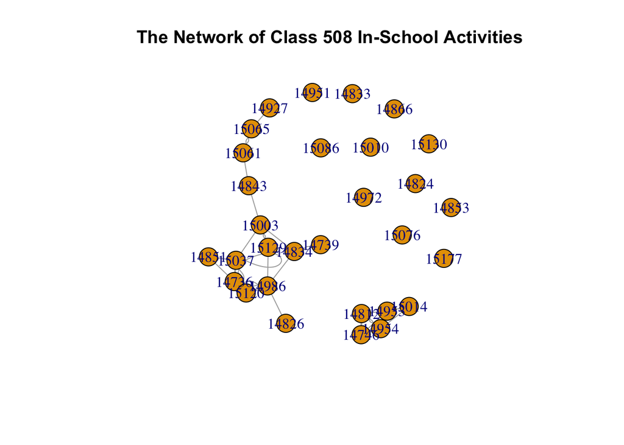

```r
plot(g1, main="The Network of Class 508 In-School Activities")
```

```r
g1
```

```
## IGRAPH 6bf2af4 UN-- 30 38 --
## + attr: name (v/c), timea (e/n), ona (e/n), oca (e/n), acta (e/n),
## | nacta (e/n), wrka (e/n), nbra (e/n), otha (e/n), wkna (e/n), bfa
## | (e/n), lva (e/n), cls_id (e/n)
## + edges from 6bf2af4 (vertex names):
##  [1] 14851--14736 14736--14986 15037--14736 14736--15120 14739--14834
##  [6] 14746--14812 14746--14953 14746--14954 14746--14812 14812--14953
## [11] 14812--14954 14739--14834 14851--15037 14746--14954 14812--14954
## [16] 14953--14954 14736--14986 14826--14986 14986--14834 14986--15120
## [21] 14986--15129 15003--14834 14843--15003 15003--15037 15003--15129
## [26] 14953--15014 14954--15014 15037--14736 15037--15037 15037--15120
## + ... omitted several edges
```

##### The Edges of The Network of Class 508 Out-of-School Activities

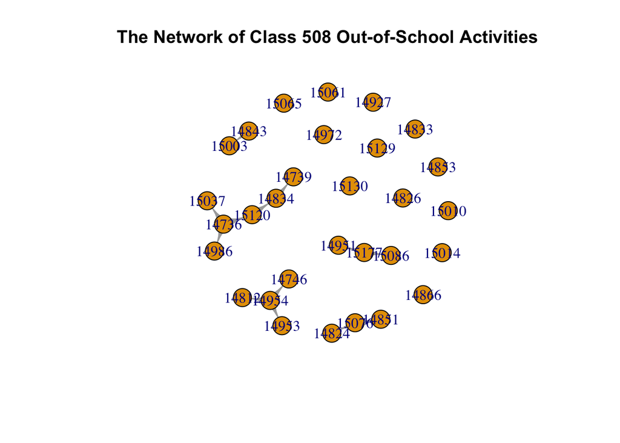

```r
plot(g2,main="The Network of Class 508 Out-of-School Activities")
```

```r
g2
```

```
## IGRAPH 8fdfbca DN-- 30 13 --
## + attr: name (v/c), timea (e/n), ona (e/n), oca (e/n), acta (e/n),
## | nacta (e/n), wrka (e/n), nbra (e/n), otha (e/n), wkna (e/n), bfa
## | (e/n), lva (e/n), cls_id (e/n)
## + edges from 8fdfbca (vertex names):
##  [1] 14736->14986 14736->15037 14736->15120 14834->14739 14843->15003
##  [6] 14954->14746 14954->14812 14954->14953 15076->14824 15076->14851
## [11] 15120->14834 15177->14951 15177->15086
```